# GSE75010 Cell Type Proportion by Case-control status Beta Regression

Kyle Campbell

1/1/2021

Using 2000 max signature genes per class and no min expr

```r
merged <- readRDS(paste0(data_dir, "GSE75010_with_abundances2021-01-26.rda"))
```

Summary stats about the correlation measurement

```r
describe(merged$Correlation)
```

```
##    vars   n mean   sd median trimmed  mad  min  max range  skew kurtosis se
## X1    1 330 0.71 0.03   0.72    0.71 0.03 0.59 0.78  0.18 -0.34    -0.02  0
```

Run Levene’s test for homogeneity of variance.

```r
leveneTest(ga ~ batch, data = merged)
```

```
## Levene's Test for Homogeneity of Variance (center = median)
##        Df F value    Pr(>F)
## group   7  25.594 < 2.2e-16 ***
##       322
## ---
## Signif. codes:  0 '***' 0.001 '**' 0.01 '*' 0.05 '.' 0.1 ' ' 1
```

table1 r package to do descriptive statistics https://cran.r-project.org/web/packages/table1/vignettes/table1-examples.html

Need to create an empty stratum for the variable you want to test by.

```r
t1 <- merged
t1$phenotype <- factor(t1$phenotype, levels = c("C", "PE", "99"), labels = c("Control", "Preeclampsia", "P-value"))
t1$sex <- factor(t1$sex, levels = c("F", "M"), labels = c("Female", "Male"))

label(t1$phenotype) <- "Preeclampsia"
label(t1$sex) <- "Fetal Sex"
label(t1$batch) <- "Study"
label(t1$ga) <- "Gestational Age"

units(t1$ga) <- "wks"
```

Custom code from the package authors to add p-value column. An empty stratum called P-value is required for the variable you are testing. rndr function will need to be adpated to each specific situation, including the entering the dataframe you wish to use and the statistical test to use for numeric and non-numeric columns. rndr.strat does not need to be modified. Statistically signifianct digits can https://cran.r-project.org/web/packages/table1/vignettes/table1-examples.html#a-column-of-p-values

```r
rndr <- function(x, name, ...) {
    if (length(x) == 0) {
        # RHS needs to correspond to the dataframe you input to t1()
        y <- t1[[name]]
        s <- rep("", length(render.default(x=y, name=name, ...)))
        if (is.numeric(y)) {
            # RHS needs to correspond to the dataframe you input to t1()
            # If the column is numeric, set the desired statistical test, T-test here
            p <- t.test(y ~ t1$phenotype)$p.value
        } else {
            #Again droplevels() argument needs to be the dataframe you input to t1()
            # If the column is not numeric, set the desired statistical test, Chi-square here
            p <- chisq.test(table(y, droplevels(t1$phenotype)))$p.value
        }
        s[2] <- sub("<", "&lt;", format.pval(p, digits=2, eps=0.001))
        s
    } else {
        render.default(x=x, name=name, ...)
    }
}

rndr.groups <- function(x, name, ...) {
    if (length(x) == 0) {
        # RHS needs to correspond to the dataframe you input to t1()
        y <- t1[[name]]
        s <- rep("", length(render.default(x=y, name=name, ...)))
        if (is.numeric(y)) {
            # RHS needs to correspond to the dataframe you input to t1()
            # If the column is numeric, set the desired statistical test, Kruskal-Wallis here
            p <- kruskal.test(y ~ t1$batch)$p.value
        } else {
            #Again droplevels() argument needs to be the dataframe you input to t1()
            # If the column is not numeric, set the desired statistical test, Chi-square here
            p <- chisq.test(table(y, droplevels(t1$batch)))$p.value
        }
        s[2] <- sub("<", "&lt;", format.pval(p, digits=2, eps=0.001))
        s
    } else {
        render.default(x=x, name=name, ...)
    }
}

rndr.strat <- function(label, n, ...) {
    ifelse(n==0, label, render.strat.default(label, n, ...))
}
```

Bivariate outcome with t-test for continuous variables and Chi-square test for categorical outcomes.

```r
table1(~ sex + ga + batch | phenotype, data=t1, droplevels=F, render=rndr, render.strat=rndr.strat, overall=F)
```

|  | Control (N=173) | Preeclampsia (N=157) | P-value |
| --- | --- | --- | --- |
| Fetal Sex |  |  |  |
| Female | 78 (45.1%) | 81 (51.6%) | 0.28 |
| Male | 95 (54.9%) | 76 (48.4%) |  |
| Gestational Age (wks) |  |  |  |
| Mean (SD) | 35.2 (3.97) | 33.0 (3.17) | <0.001 |
| Median [Min, Max] | 37.0 [25.0, 41.0] | 33.0 [25.0, 39.0] |  |
| Study |  |  |  |
| GSE10588 | 26 (15.0%) | 17 (10.8%) | 0.39 |
| GSE24129 | 8 (4.6%) | 8 (5.1%) |  |
| GSE25906 | 37 (21.4%) | 23 (14.6%) |  |
| GSE30186 | 6 (3.5%) | 6 (3.8%) |  |
| GSE43942 | 7 (4.0%) | 5 (3.2%) |  |
| GSE44711 | 8 (4.6%) | 8 (5.1%) |  |
| GSE4707 | 4 (2.3%) | 10 (6.4%) |  |
| GSE75010 | 77 (44.5%) | 80 (51.0%) |  |

Bivariate batch with Kruskal-Wallis ANOVA (regular ANOVA homogeneity of variances violated) for continuous variables and Chi-square test for categorical outcomes.

```r
t1$phenotype <- droplevels(t1$phenotype)
label(t1$phenotype) <- "Preeclampsia"
t1$batch <- factor(t1$batch, levels = append(levels(t1$batch), "99"), labels = append(levels(t1$batch), "P-value"))

table1(~ sex + ga + phenotype | batch, data=t1, droplevels=F, render=rndr.groups, render.strat=rndr.strat, overall=F)
```

|  | GSE10588 (N=43) | GSE24129 (N=16) | GSE25906 (N=60) | GSE30186 (N=12) | GSE43942 (N=12) | GSE44711 (N=16) | GSE4707 (N=14) | GSE75010 (N=157) | P-value |
| --- | --- | --- | --- | --- | --- | --- | --- | --- | --- |
| Fetal Sex |  |  |  |  |  |  |  |  |  |
| Female | 22 (51.2%) | 6 (37.5%) | 29 (48.3%) | 7 (58.3%) | 8 (66.7%) | 6 (37.5%) | 7 (50.0%) | 74 (47.1%) | 0.8 |
| Male | 21 (48.8%) | 10 (62.5%) | 31 (51.7%) | 5 (41.7%) | 4 (33.3%) | 10 (62.5%) | 7 (50.0%) | 83 (52.9%) |  |
| Gestational Age (wks) |  |  |  |  |  |  |  |  |  |
| Mean (SD) | 34.0 (0) | 34.5 (3.61) | 36.4 (3.17) | 37.5 (1.57) | 37.3 (2.06) | 31.9 (3.59) | 33.0 (0) | 33.1 (4.25) | <0.001 |
| Median [Min, Max] | 34.0 [34.0, 34.0] | 34.5 [31.0, 38.0] | 37.0 [27.0, 40.0] | 37.5 [36.0, 39.0] | 39.0 [35.0, 39.0] | 32.5 [25.0, 37.0] | 33.0 [33.0, 33.0] | 33.0 [25.0, 41.0] |  |
| Preeclampsia |  |  |  |  |  |  |  |  |  |
| Control | 26 (60.5%) | 8 (50.0%) | 37 (61.7%) | 6 (50.0%) | 7 (58.3%) | 8 (50.0%) | 4 (28.6%) | 77 (49.0%) | 0.39 |
| Preeclampsia | 17 (39.5%) | 8 (50.0%) | 23 (38.3%) | 6 (50.0%) | 5 (41.7%) | 8 (50.0%) | 10 (71.4%) | 80 (51.0%) |  |

```r
t1$batch <- droplevels(t1$batch)
label(t1$batch) <- "Batch"
```

## Cell Type Proportions Exploration and Dimension Reduction

Code based on http://www.sthda.com/english/articles/31-principal-component-methods-in-r-practical-guide/118-principal-component-analysis-in-r-prcomp-vs-princomp/.

Prep data for PCA - extract only the active variables and drop Fetal Naive CD4+ T Cells and Fetal B cells because 0% predicted for each observation.

```r
# Select only the cell type proportions
active <-
  merged %>%
  dplyr::select(!c(sample, phenotype, batch, ga, sex, "P-value", RMSE, Correlation, "Fetal Naive CD4+ T Cells", "Fetal B Cells"))
# Assign sample IDs to rownames of cell type proportions
rownames(active) <- merged$sample
```

Run PCA

```r
res.pca <- prcomp(active, scale = F)
#saveRDS(res.pca, paste0(data_dir, "GSE75010_cell_type_proportions_pca_", Sys.Date(), ".rda"))
pca.summary <- summary(res.pca)

prop.var <- as.data.frame(pca.summary$importance)

# The first 5 components provide almost 78% of the variance explained.
sum(prop.var[2,1:5])
```

```
## [1] 0.77726
```

https://blog.bioturing.com/2018/06/18/how-to-read-pca-biplots-and-scree-plots/ briefly summarizes applied PCA analysis. Scree plot

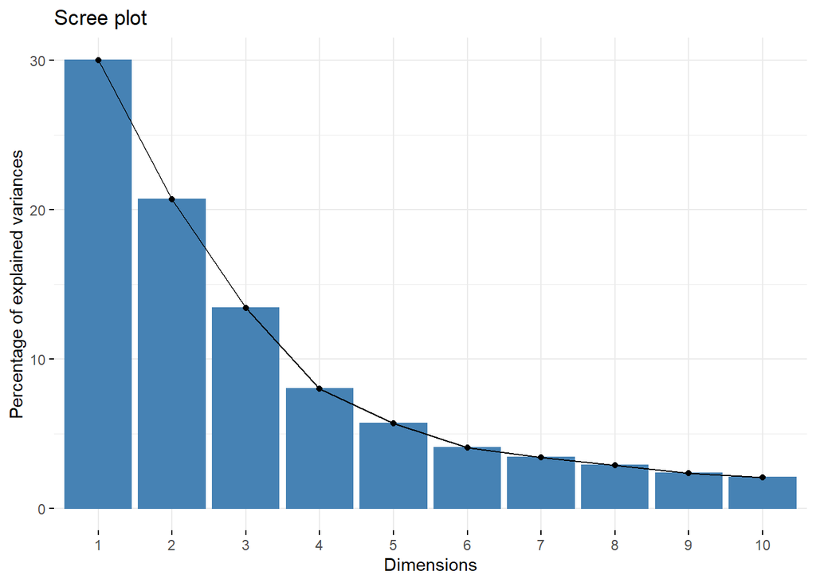

```r
fviz_eig(res.pca)
```

```r
#View(abs(res.pca$rotation))
colSums(res.pca$rotation)
```

```
##           PC1           PC2           PC3           PC4           PC5
##  0.0003136078  0.0011981273 -0.0096745466  0.0288308682 -0.0050336691
##           PC6           PC7           PC8           PC9          PC10
##  0.0143873506 -0.0238475922  0.0247576076  0.0112962669  0.0052451522
##          PC11          PC12          PC13          PC14          PC15
## -0.0043645142  0.0177403971 -0.0315233835  0.0158934575  0.0049915733
##          PC16          PC17          PC18          PC19          PC20
##  0.0009735917  0.0746584583 -0.0478158521 -0.0740622910 -0.2351398802
##          PC21          PC22          PC23          PC24          PC25
##  0.0714803706 -0.0416376315 -0.1091299174  0.7339371706 -4.9365824333
```

```r
#View(res.pca$center)
```

Graph of individuals. Individuals with a similar profile are grouped together.

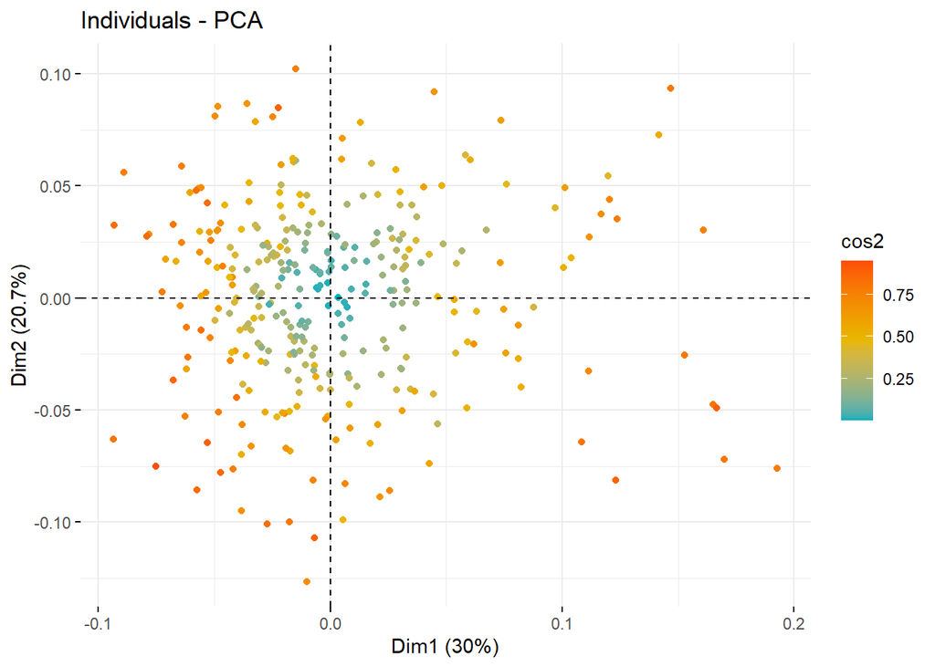

```r
fviz_pca_ind(res.pca,
             col.ind = "cos2", # Color by the quality of representation
             gradient.cols = c("#00AFBB", "#E7B800", "#FC4E07"),
             label = F
             )
```

Graph of variables. Positively correlated variables point to the same side of the plot. Negatively correlated variables point to opposite sides of the graph

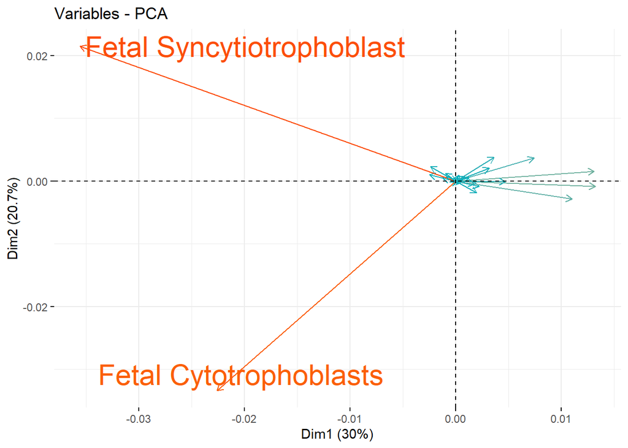

```r
pc.1.2 <- fviz_pca_var(res.pca,
             col.var = "contrib", # Color by contributions to the PC
             gradient.cols = c("#00AFBB", "#E7B800", "#FC4E07"),
             legend.title = "Contribution",
             # Default labelsize = 4
             labelsize = 2*4,
             repel = TRUE,      # Avoid text overlapping
             ) +
  theme(legend.position = "none")
pc.1.2
```

```r
#ggsave(paste0(results_dir, "variables_pca_1_2_", Sys.Date(), ".png"))
```

```r
#print(res.pca$rotation)
loadings <-res.pca$rotation
```

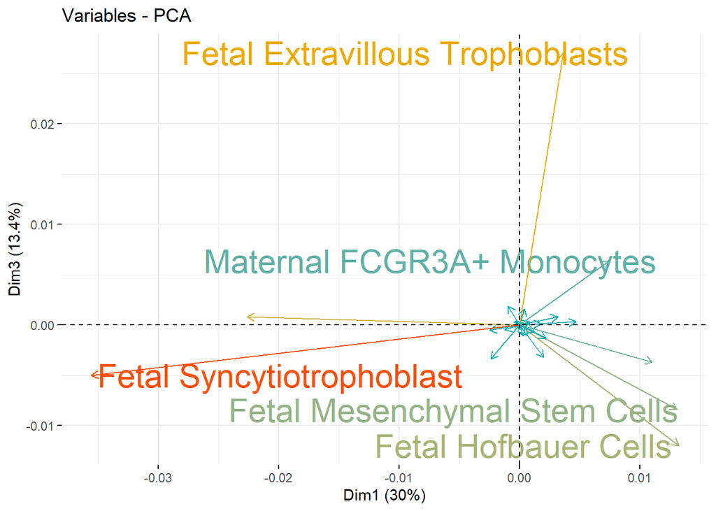

```r
pc.1.3 <- fviz_pca_var(res.pca,
             axes = c(1,3),
             col.var = "contrib", # Color by contributions to the PC
             gradient.cols = c("#00AFBB", "#E7B800", "#FC4E07"),
             legend.title = "Contribution",
             # Default labelsize = 4
             labelsize = 2*4,
             repel = TRUE,     # Avoid text overlapping
             ) +
  theme(legend.position = "none")
pc.1.3
```

```r
#ggsave(paste0(results_dir, "variables_pca_1_3_", Sys.Date(), ".png"))
```

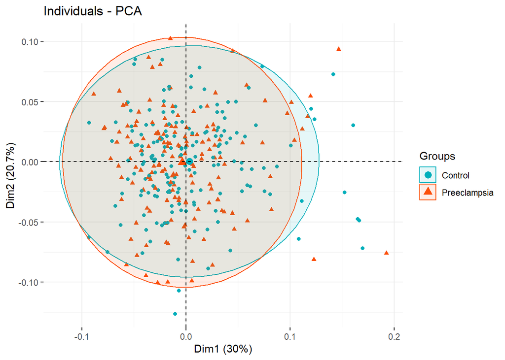

```r
groups <- t1$phenotype
fviz_pca_ind(res.pca,
             col.ind = groups, # color by groups
             palette = c("#00AFBB",  "#FC4E07"),
             addEllipses = TRUE, # Concentration ellipses
             legend.title = "Groups",
             repel = TRUE,
             label = F
             )
```

```r
#ggsave(paste0(results_dir, "individuals_pca_", Sys.Date(), ".png"))
#ggsave(paste0(results_dir, "individuals_pca_2021-01-25.png"))
```

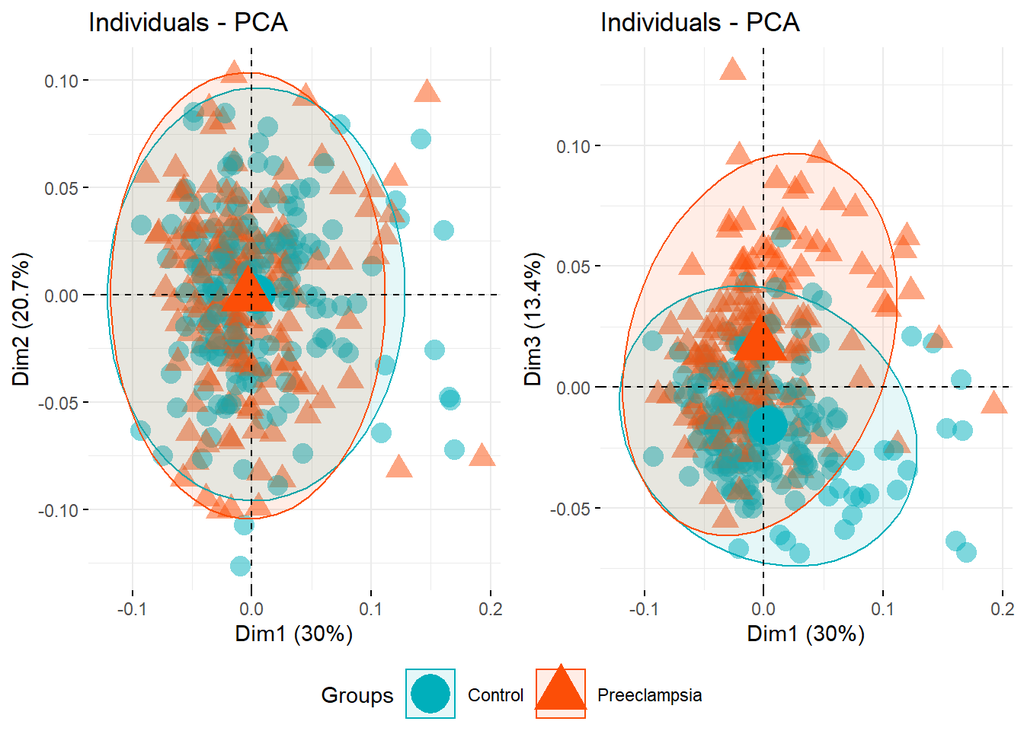

```r
# Set up PC combinations to loop over
dims <- list(
  c(1,2), c(1,3), c(1,4),
  c(2,3), c(2,4),
  c(3,4)
)
# Add names
names(dims) <- c("12", "13", "14", "23", "24", "34")

# Apply fviz_pca_ind over desired pc combinations
pc_inds <- lapply(dims, function(x) fviz_pca_ind(
    res.pca,
    axes = x,
    col.ind = groups,
    # Default pointsize = 1.5
    pointsize = 3*1.5,
    alpha = .5,
    # color by groups
    palette = c("#00AFBB",  "#FC4E07"),
    addEllipses = TRUE,
    # Concentration ellipses
    legend.title = "Groups",
    repel = TRUE,
    label = F
  ) + theme(legend.position = "none"))

ggarrange(pc_inds$`12`, pc_inds$`13`,
          common.legend = TRUE, legend = "bottom")
```

Make presentable graphs

```r
pc.plots <- list(
  "loadings.1.2" = pc.1.2 + ggtitle("Loadings Plot - PC1xPC2"),
  "loadings.1.3" = pc.1.3 + ggtitle("Loadings Plot - PC1xPC3"),
  "observations.1.2" = pc_inds$`12` + ggtitle("PCA Plot - PC1xPC2"),
  "observations.1.3" = pc_inds$`13` + ggtitle("PCA Plot - PC1xPC3")
)

# Input ggplot to get x and y limits for graph
get_coord_limits <- function(ggplot) {

  # Get build options
  build <- ggplot_build(ggplot)
  # Get x-limits
  x <- build$layout$panel_scales_x[[1]]$range$range
  # Get y-limits
  y <- build$layout$panel_scales_y[[1]]$range$range

  # Return x and y limits as list
  return(list(
    "x" = x,
    "y" = y
  ))
}

# Pull limits from each graph
limits <- map(pc.plots[1:2], ~ get_coord_limits(.x))

# Pull x-limits and convert to list of vectors
x_limits <- map(limits, ~ unlist(.x["x"]))
# Convert x-limits to vector
x_limits <- unlist(x_limits)
# Get x-min
x_min <- min(x_limits)
# Get x-max
x_max <- max(x_limits)

# Pull y-limits and convert to list of vectors
y_limits <- map(limits, ~ unlist(.x["y"]))
# Convert y-limits to vector
y_limits <- unlist(y_limits)
# Get y-min
y_min <- min(y_limits)
# Get y-max
#y_sorted <- sort(y_limits)
#y_max <- y_sorted[length(y_sorted)-3] %>% as.numeric
y_max <- max(y_limits)

plots.loadings <- map(pc.plots[1:2], ~.x + coord_cartesian(xlim = c(x_min, x_max), ylim = c(y_min, y_max)))

# Pull limits from each graph
limits <- map(pc.plots[3:4], ~ get_coord_limits(.x))

# Pull x-limits and convert to list of vectors
x_limits <- map(limits, ~ unlist(.x["x"]))
# Convert x-limits to vector
x_limits <- unlist(x_limits)
# Get x-min
x_min <- min(x_limits)
# Get x-max
x_max <- max(x_limits)

# Pull y-limits and convert to list of vectors
y_limits <- map(limits, ~ unlist(.x["y"]))
# Convert y-limits to vector
y_limits <- unlist(y_limits)
# Get y-min
y_min <- min(y_limits)
# Get y-max
#y_sorted <- sort(y_limits)
#y_max <- y_sorted[length(y_sorted)-3] %>% as.numeric
y_max <- max(y_limits)

plots.observations <- map(pc.plots[3:4], ~.x + coord_cartesian(xlim = c(x_min, x_max), ylim = c(y_min, y_max)))

pc.plots <- c(plots.loadings, plots.observations)
pc.plots <- map(pc.plots, ~ .x + theme_minimal(base_size = 20))
pc.plots[1:2] <- map(pc.plots[1:2], ~ .x + theme(legend.position = "none"))
#pc.plots[3:4] <- map(pc.plots[3:4], ~ .x + )
```

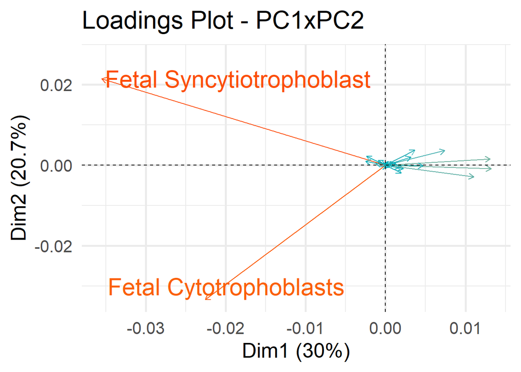

```r
pc.plots$loadings.1.2
```

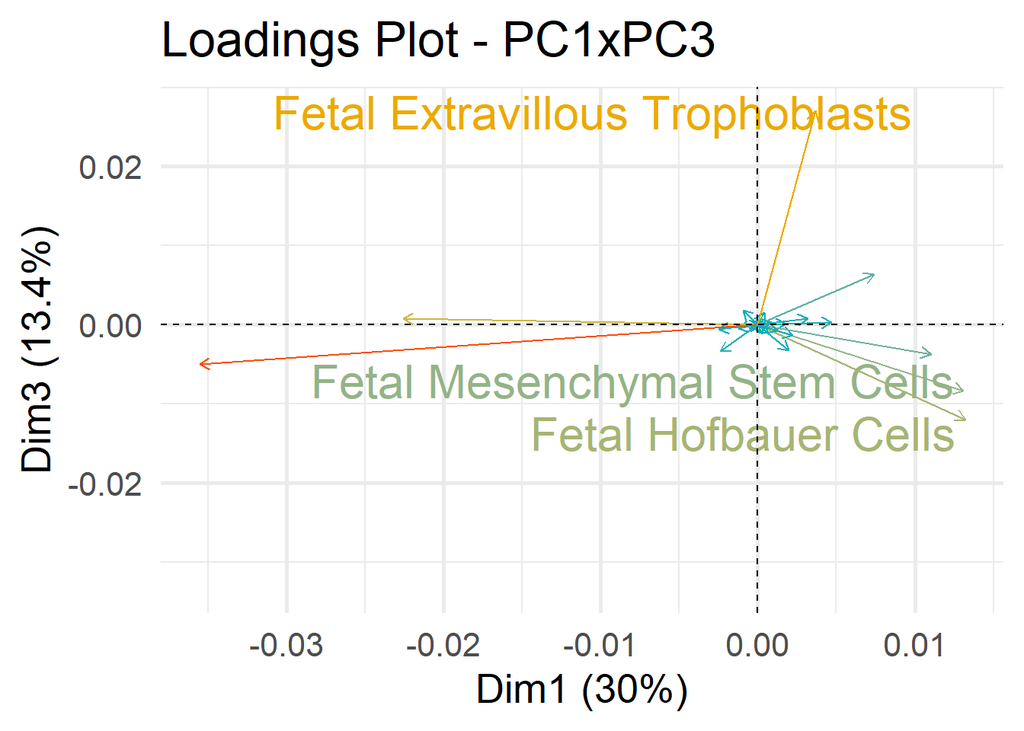

```r
pc.plots$loadings.1.3
```

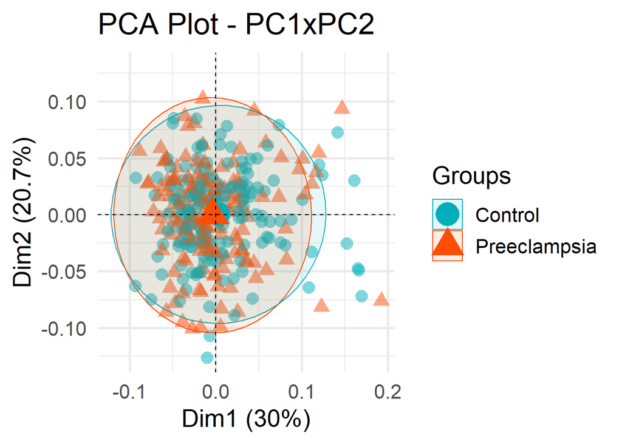

```r
pc.plots$observations.1.2
```

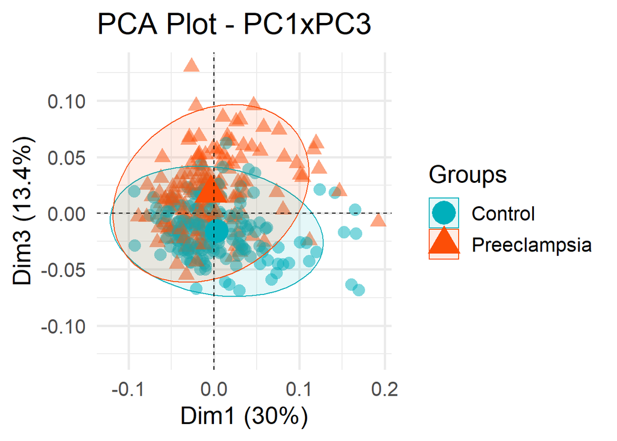

```r
pc.plots$observations.1.3
```

Common legends

```r
loadings <- ggarrange(pc.plots$loadings.1.2, pc.plots$loadings.1.3, labels = c("A", "B"), common.legend = TRUE, legend = "bottom", font.label = list(size = 24, face = "bold", color = "black"))
observations <- ggarrange(pc.plots$observations.1.2, pc.plots$observations.1.3, labels = c("C", "D"), common.legend = TRUE, legend = "bottom", font.label = list(size = 24, face = "bold", color = "black"))
```

Summary and graph of PCA results.

```r
panel <- ggarrange(loadings, observations, nrow = 2, ncol = 1)
#ggexport(panel, filename = here("results", "GSE75010", paste0(Sys.Date(), "_PCA_plots.png")), width = 1920, height = 1080)
```

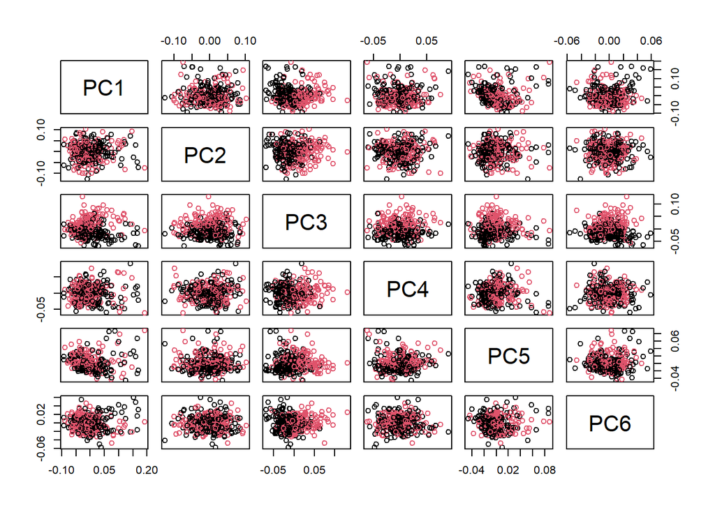

```r
# Pull phenotype column
sample <- merged$sample
phenotype <- merged$phenotype

# Pull PC values
pca.df <- as.data.frame(res.pca$x)

# Add metadata
pca.df <- cbind(pca.df, sample)
pca.df <- cbind(pca.df, phenotype)

#dev.new()
#pdf(paste0(results_dir, "PC_matrix_", Sys.Date(), ".pdf"))
pairs(pca.df[1:6], col=pca.df$phenotype)
```

```r
#dev.off()
```

Calculate the coordinates for the levels of grouping variables. The coordinates for a given group is calculated as the mean coordinates of the individuals in the group.

```r
# 1. Individual coordinates
res.ind <- get_pca_ind(res.pca)
# 2. Coordinate of groups
coord.groups <- res.ind$coord %>%
  as_data_frame() %>%
  dplyr::select(Dim.1, Dim.2, Dim.3) %>%
  mutate(category = groups) %>%
  group_by(category) %>%
  summarise(
    Dim.1 = mean(Dim.1),
    Dim.2 = mean(Dim.2),
    Dim.3 = mean(Dim.3)
    )
coord.groups
```

```
## # A tibble: 2 x 4
##   category        Dim.1     Dim.2   Dim.3
##   <fct>           <dbl>     <dbl>   <dbl>
## 1 Control       0.00331  0.000325 -0.0160
## 2 Preeclampsia -0.00365 -0.000358  0.0177
```

Project gestational age onto PC1xPC2. The coordinates of a given quantitative variable are calculated as the correlation between the quantitative variable and the principal components.

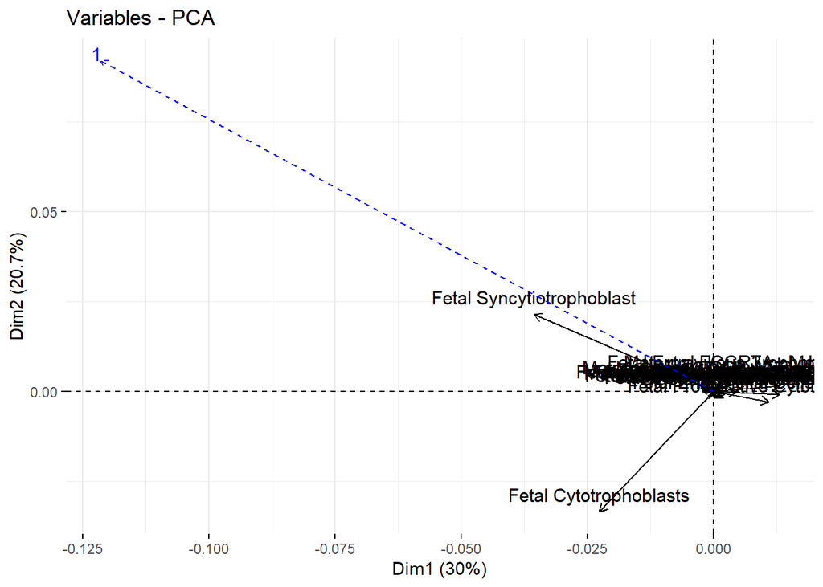

```r
ga <- t1$ga
# Predict coordinates and compute cos2
quanti.coord <- cor(ga, res.pca$x)
quanti.cos2 <- quanti.coord^2
# Graph of variables including supplementary variables
p <- fviz_pca_var(res.pca)
fviz_add(p, quanti.coord, color ="blue", geom="arrow")
```

```r
#ggsave(paste0(results_dir, "variables_pca_plus_ga_", Sys.Date(), ".png"))
```

```r
# Helper function
#::::::::::::::::::::::::::::::::::::::::
var_coord_func <- function(loadings, comp.sdev){
  loadings*comp.sdev
}
# Compute Coordinates
#::::::::::::::::::::::::::::::::::::::::
loadings <- res.pca$rotation
sdev <- res.pca$sdev
var.coord <- t(apply(loadings, 1, var_coord_func, sdev))
head(var.coord[, 1:4])
```

```
##                                        PC1           PC2           PC3
## Fetal Mesenchymal Stem Cells  0.0131018418  0.0015675656 -0.0083651424
## Fetal CD14+ Monocytes        -0.0002444692 -0.0001326986  0.0002768245
## Fetal CD8+ Cytotoxic T Cells  0.0017709814 -0.0004452990  0.0001364369
## Fetal Naive CD8+ T Cells     -0.0012367800  0.0004732010 -0.0004795855
## Fetal Natural Killer T Cells -0.0003757069  0.0004091961  0.0004296699
## Fetal Cytotrophoblasts       -0.0226006086 -0.0333779307  0.0008161201
##                                        PC4
## Fetal Mesenchymal Stem Cells  0.0006774450
## Fetal CD14+ Monocytes        -0.0063018102
## Fetal CD8+ Cytotoxic T Cells -0.0004333388
## Fetal Naive CD8+ T Cells     -0.0168814701
## Fetal Natural Killer T Cells -0.0007186750
## Fetal Cytotrophoblasts        0.0020369710
```

```r
# Compute Cos2
#::::::::::::::::::::::::::::::::::::::::
var.cos2 <- var.coord^2
head(var.cos2[, 1:4])
```

```
##                                       PC1          PC2          PC3
## Fetal Mesenchymal Stem Cells 1.716583e-04 2.457262e-06 6.997561e-05
## Fetal CD14+ Monocytes        5.976517e-08 1.760891e-08 7.663179e-08
## Fetal CD8+ Cytotoxic T Cells 3.136375e-06 1.982912e-07 1.861502e-08
## Fetal Naive CD8+ T Cells     1.529625e-06 2.239192e-07 2.300023e-07
## Fetal Natural Killer T Cells 1.411557e-07 1.674414e-07 1.846162e-07
## Fetal Cytotrophoblasts       5.107875e-04 1.114086e-03 6.660520e-07
##                                       PC4
## Fetal Mesenchymal Stem Cells 4.589317e-07
## Fetal CD14+ Monocytes        3.971281e-05
## Fetal CD8+ Cytotoxic T Cells 1.877825e-07
## Fetal Naive CD8+ T Cells     2.849840e-04
## Fetal Natural Killer T Cells 5.164938e-07
## Fetal Cytotrophoblasts       4.149251e-06
```

```r
# Compute contributions
#::::::::::::::::::::::::::::::::::::::::
comp.cos2 <- apply(var.cos2, 2, sum)
contrib <- function(var.cos2, comp.cos2){var.cos2*100/comp.cos2}
var.contrib <- t(apply(var.cos2,1, contrib, comp.cos2))
head(var.contrib[, 1:4])
```

```
##                                       PC1          PC2         PC3         PC4
## Fetal Mesenchymal Stem Cells  7.231753153  0.150326978 6.605248751  0.07274472
## Fetal CD14+ Monocytes         0.002517834  0.001077254 0.007233549  6.29483021
## Fetal CD8+ Cytotoxic T Cells  0.132131665  0.012130786 0.001757138  0.02976518
## Fetal Naive CD8+ T Cells      0.064441231  0.013698617 0.021710738 45.17247728
## Fetal Natural Killer T Cells  0.005946718  0.010243500 0.017426585  0.08186881
## Fetal Cytotrophoblasts       21.518855182 68.156031237 0.062871037  0.65769279
```

```r
#View(var.contrib)
```

Interesting way to visualize the relative abundance of each cell type

```r
annotation.row <- data.frame(Phenotype = t1$phenotype)

#pheatmap(active, cutree_rows = 2, annotation_row = annotation.row)
```

Corrplot to identify inversely correlated proportions. Maternal plasma and B cells are inversely correlated as well as Maternal NK/Fetal CD8+ cytotoxic

```r
# Compute a correlation matrix
corr <- round(cor(active), 3)
```

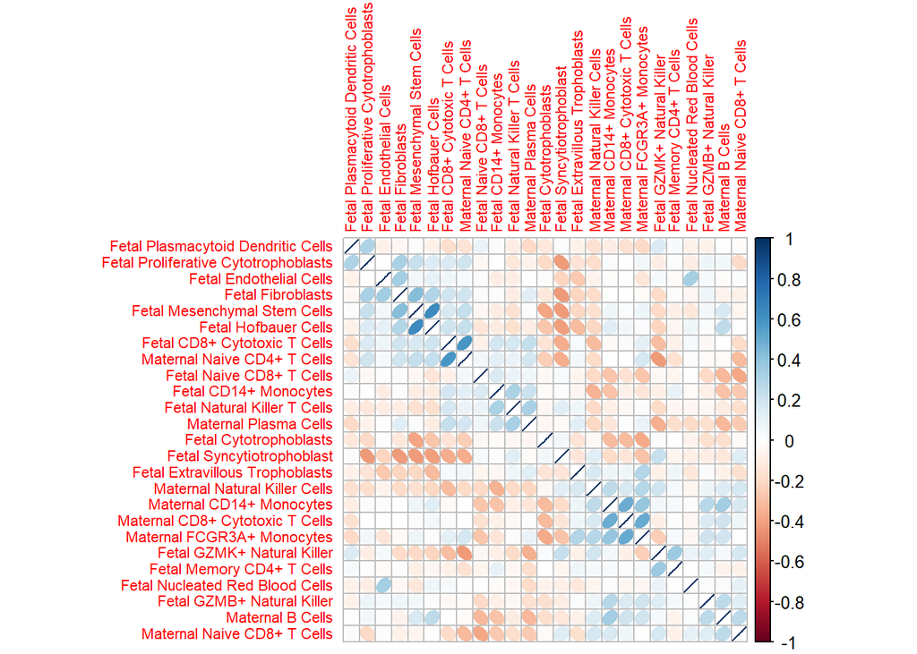

```r
#dev.new()
#pdf(paste0(results_dir, "cell_type_props_corrplot_", Sys.Date(), ".pdf"))
corrplot(corr, method = "ellipse", order = "hclust", tl.cex = .7) #tl.cex control axis label size
```

```r
#dev.off()

# Alternative options
#corrplot(corr, method = "ellipse", order = "hclust")
#corrplot(corr, method = "ellipse", order = "AOE")
```

## Graphing Cell Type Proportions

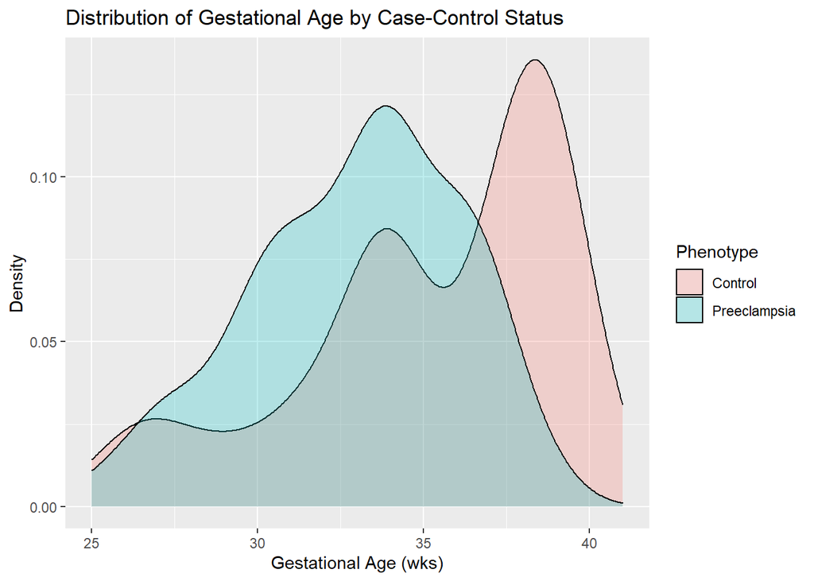

```r
graph <- merged
levels(graph$phenotype) <- c("Control", "Preeclampsia")
ggplot(graph,aes(x=ga, fill=phenotype)) + geom_density(alpha=0.25) +
  ggtitle("Distribution of Gestational Age by Case-Control Status") +
  xlab("Gestational Age (wks)") + ylab("Density") + labs(fill = "Phenotype")
```

```r
#ggsave(paste0(results_dir, "ga_distribution_by_case-control_", Sys.Date(), ".png"))
```

Custom function to graph variables by group via Violin Plot.

```r
# DATA: dataframe that contains data of interest
# GROUP: MUST be character vector
# VARIABLES: MUST be character vector
violin_compare_groups <- function(data, group, variables) {
  violins <- list()
  for(variable in variables) {
      violins[[variable]] <- ggplot(data, aes(.data[[group]], .data[[variable]])) + geom_violin()
  }
  return(violins)
}
cell.types <- colnames(merged)[6:19]
violins <- violin_compare_groups(merged, "phenotype", cell.types)
```

Convert to long data format for graphing purposes

```r
# Remove the unnecessary columns
# Select was masked, had to add dplyr::
merged.violin <- merged %>% dplyr::select(!c('P-value', Correlation, RMSE))

#long <- gather(merged.violin, cell_type, proportion, fibroblasts:extravillous_trophoblasts, factor_key = T)
long <- gather(merged.violin, 'Cell Type', Proportion, 'Fetal Mesenchymal Stem Cells':'Fetal Extravillous Trophoblasts', factor_key = T)

# Rename factors for graphing purposes
levels(long$phenotype) <- c("Control", "Preeclampsia")
#levels(long$cell_type) <- c("Fibroblasts", "Activated T-cells", "CD14 Monocytes", "Naive T-cells", "Natural Killer", "FCGR3A Monocytes", "B Cells", "Cytotrophoblasts" , "Hofbauer Cells", "pDC", "Endothelial", "Syncytiotrophoblast", "npiCytotrophoblasts", " Extravillous")

#long.nosyn <- long %>% filter(cell_type != "Syncytiotrophoblast")
#long.syn <- long %>% filter(cell_type == "Syncytiotrophoblast")
```

Stacked bar chart of cell type proportions by sample

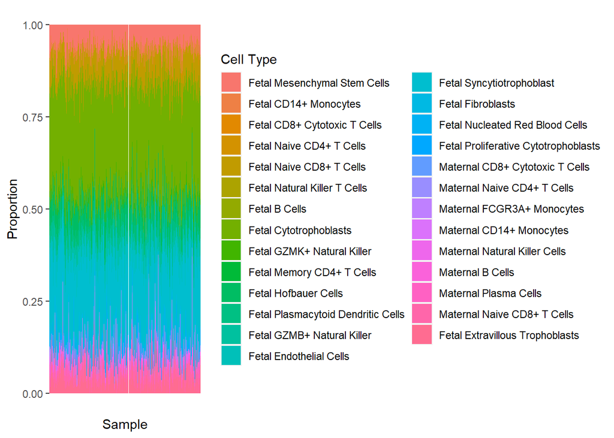

```r
stacked.bar <- ggplot(long, aes(fill = `Cell Type`, x = sample, y = Proportion)) + geom_bar(postion = "stack", stat = "identity")
stacked.bar + theme(axis.text.x=element_blank(), axis.ticks.x = element_blank()) + xlab("Sample")
```

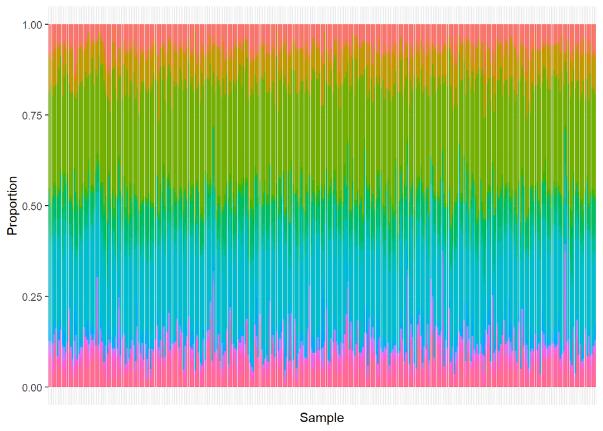

```r
stacked.bar + theme(legend.position = "none", axis.text.x=element_blank(), axis.ticks.x = element_blank()) + xlab("Sample")
```

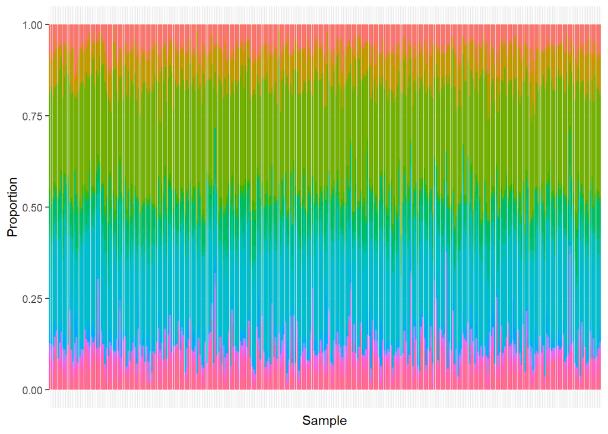

```r
stacked.bar + theme(legend.position = "none", axis.text.x=element_blank(), axis.ticks.x = element_blank()) + xlab("Sample")
```

```r
#ggsave(here("results", "GSE75010", paste0("/", Sys.Date(), "_stacked_cell_type_proportions.png")))
```

```r
#long.placenta <- long %>%
#  dplyr::filter(cell_type %in% c("Fibroblasts", "Cytotrophoblasts" , "Hofbauer Cells", "Endothelial", "Syncytiotrophoblast", #"npiCytotrophoblasts", " Extravillous"))
#long.immune <- long %>%
#  dplyr::filter(!cell_type %in% c("Fibroblasts", "Cytotrophoblasts" , "Hofbauer Cells", "Endothelial", "Syncytiotrophoblast", #"npiCytotrophoblasts", " Extravillous"))

long.fetal <- long %>%
  dplyr::filter(grepl("Fetal ", `Cell Type`))

long.maternal <- long %>%
  dplyr::filter(grepl("Maternal ", `Cell Type`))

# Make syntactically valid names
colnames(long.fetal)<- make.names(colnames(long.fetal))
colnames(long.maternal)<- make.names(colnames(long.maternal))
```

Graphing note: scale = “width” argument required rather than ggplot2 default of scale = “area” for this dataset

TODO cleanup x-axis label

https://cran.r-project.org/web/packages/ggridges/vignettes/gallery.html

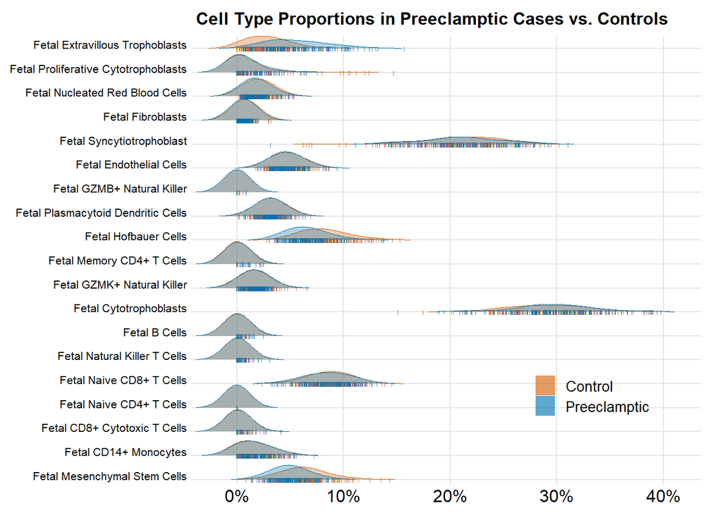

```r
fetal <- ggplot(long.fetal, aes(x = Proportion, y = Cell.Type, color = phenotype, point_color = phenotype, fill = phenotype)) +
  geom_density_ridges(
    jittered_points = TRUE, scale = .95, rel_min_height = .01,
    point_shape = "|", point_size = 1, size = 0.25,
    position = position_points_jitter(height = 0)
  ) +
  ylab("Cell Type") +
  scale_y_discrete(expand = c(0, 0)) +
  scale_x_continuous(expand = c(0, 0), name = "Cell Type Proportion", labels = scales::percent_format(accuracy = 1)) +
  scale_fill_manual(values = c("#D55E0050", "#0072B250"), labels = c("Control", "Preeclamptic")) +
  scale_color_manual(values = c("#D55E00", "#0072B2"), guide = "none") +
  scale_discrete_manual("point_color", values = c("#D55E00", "#0072B2"), guide = "none") +
  coord_cartesian(clip = "off") +
  guides(fill = guide_legend(
    override.aes = list(
      fill = c("#D55E00A0", "#0072B2A0"),
      color = NA, point_color = NA)
    )
  ) +
  ggtitle("Cell Type Proportions in Preeclamptic Cases vs. Controls") +
  theme_ridges(center = TRUE) +
  theme(legend.title = element_blank(), legend.position = c(.65, .2), legend.text = element_text(size = 10), axis.title.x=element_blank(), plot.title = element_text(size = 12), axis.text.y = element_text(size = 8), axis.title.y = element_blank())

fetal.panel <- ggplot(long.fetal, aes(x = Proportion, y = Cell.Type, color = phenotype, point_color = phenotype, fill = phenotype)) +
  geom_density_ridges(
    jittered_points = TRUE, scale = .95, rel_min_height = .01,
    point_shape = "|", point_size = 1, size = 0.25,
    position = position_points_jitter(height = 0)
  ) +
  ylab("Cell Type") +
  labs(fill = "Case-control Status") +
  scale_y_discrete(expand = c(0, 0)) +
  scale_x_continuous(expand = c(0, 0), name = "Cell Type Proportion", labels = scales::percent_format(accuracy = 1)) +
  scale_fill_manual(values = c("#D55E0050", "#0072B250"), labels = c("Control", "Preeclamptic")) +
  scale_color_manual(values = c("#D55E00", "#0072B2"), guide = "none") +
  scale_discrete_manual("point_color", values = c("#D55E00", "#0072B2"), guide = "none") +
  coord_cartesian(clip = "off") +
  guides(fill = guide_legend(
    override.aes = list(
      fill = c("#D55E00A0", "#0072B2A0"),
      color = NA, point_color = NA)
    )
  ) +
  ggtitle("Cell Type Proportions in Preeclamptic Cases vs. Controls") +
  theme_minimal(base_size = 20) +
  theme(axis.text.y = element_text(color = "black"))
  #theme_ridges(center = TRUE) +
  #theme(legend.title = element_blank(), legend.position = c(.65, .2), legend.text = element_text(size = 10), axis.title.x=element_blank(), plot.title = element_text(size = 12), axis.text.y = element_text(size = 8), axis.title.y = element_blank())

fetal
```

```r
#ggsave(paste0(results_dir, "fetal_bivariate_cell_type_proportion_distribution_", Sys.Date(), ".png"))
```

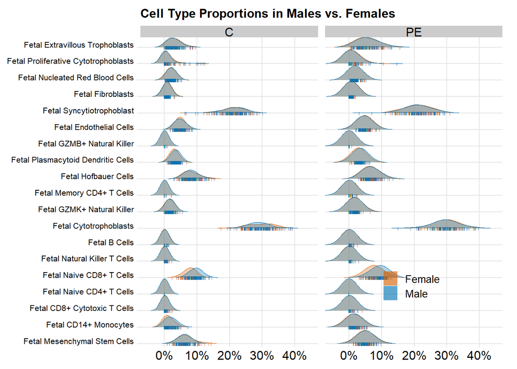

```r
fetal <- ggplot(long.fetal, aes(x = Proportion, y = Cell.Type, color = sex, point_color = sex, fill = sex)) +
  geom_density_ridges(
    jittered_points = TRUE, scale = .95, rel_min_height = .01,
    point_shape = "|", point_size = 1, size = 0.25,
    position = position_points_jitter(height = 0)
  ) +
  ylab("Cell Type") +
  scale_y_discrete(expand = c(0, 0)) +
  scale_x_continuous(expand = c(0, 0), name = "Cell Type Proportion", labels = scales::percent_format(accuracy = 1)) +
  scale_fill_manual(values = c("#D55E0050", "#0072B250"), labels = c("Female", "Male")) +
  scale_color_manual(values = c("#D55E00", "#0072B2"), guide = "none") +
  scale_discrete_manual("point_color", values = c("#D55E00", "#0072B2"), guide = "none") +
  coord_cartesian(clip = "off") +
  guides(fill = guide_legend(
    override.aes = list(
      fill = c("#D55E00A0", "#0072B2A0"),
      color = NA, point_color = NA)
    )
  ) +
  ggtitle("Cell Type Proportions in Males vs. Females") +
  theme_ridges(center = TRUE) +
  theme(legend.title = element_blank(), legend.position = c(.65, .2), legend.text = element_text(size = 10), axis.title.x=element_blank(), plot.title = element_text(size = 12), axis.text.y = element_text(size = 8), axis.title.y = element_blank()) +
  facet_wrap(phenotype)

fetal
```

```r
#ggsave(here("results", "GSE75010", paste0("/", Sys.Date(), "cell_type_props_male_v_female_preeclampsia_facet_wrap.png")))
```

```r
colnames(long.fetal)
```

```
## [1] "sample"     "phenotype"  "batch"      "ga"         "sex"
## [6] "Cell.Type"  "Proportion"
```

```r
long.fetal %>% group_by(phenotype, Cell.Type) %>% summarise(median = median(Proportion)) #%>% View
```

```
## # A tibble: 38 x 3
## # Groups:   phenotype [2]
##    phenotype Cell.Type                    median
##    <fct>     <fct>                         <dbl>
##  1 Control   Fetal Mesenchymal Stem Cells 0.0616
##  2 Control   Fetal CD14+ Monocytes        0.0112
##  3 Control   Fetal CD8+ Cytotoxic T Cells 0
##  4 Control   Fetal Naive CD4+ T Cells     0
##  5 Control   Fetal Naive CD8+ T Cells     0.0884
##  6 Control   Fetal Natural Killer T Cells 0
##  7 Control   Fetal B Cells                0
##  8 Control   Fetal Cytotrophoblasts       0.290
##  9 Control   Fetal GZMK+ Natural Killer   0.0155
## 10 Control   Fetal Memory CD4+ T Cells    0
## # ... with 28 more rows
```

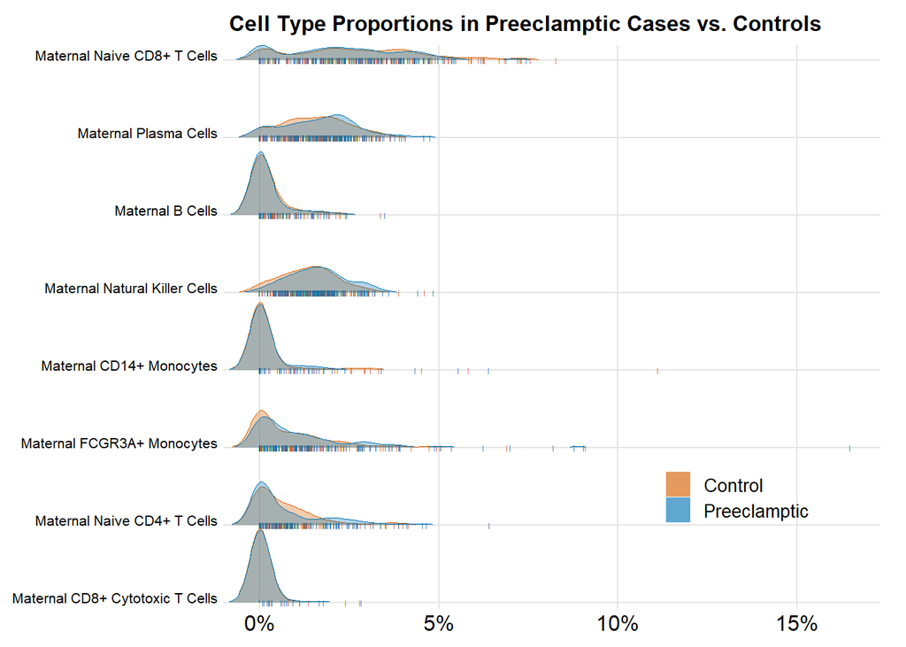

```r
maternal <-  ggplot(long.maternal, aes(x = Proportion, y = Cell.Type, color = phenotype, point_color = phenotype, fill = phenotype)) +
  geom_density_ridges(
    jittered_points = TRUE, scale = .95, rel_min_height = .01,
    point_shape = "|", point_size = 1, size = 0.25,
    position = position_points_jitter(height = 0)
  ) +
  ylab("Cell Type") +
  scale_y_discrete(expand = c(0, 0)) +
  scale_x_continuous(expand = c(0, 0), name = "Cell Type Proportion", labels = scales::percent_format(accuracy = 1)) +
  scale_fill_manual(values = c("#D55E0050", "#0072B250"), labels = c("Control", "Preeclamptic")) +
  scale_color_manual(values = c("#D55E00", "#0072B2"), guide = "none") +
  scale_discrete_manual("point_color", values = c("#D55E00", "#0072B2"), guide = "none") +
  coord_cartesian(clip = "off") +
  guides(fill = guide_legend(
    override.aes = list(
      fill = c("#D55E00A0", "#0072B2A0"),
      color = NA, point_color = NA)
    )
  ) +
  ggtitle("Cell Type Proportions in Preeclamptic Cases vs. Controls") +
  theme_ridges(center = TRUE) +
  theme(legend.title = element_blank(), legend.position = c(.65, .2), legend.text = element_text(size = 10), axis.title.x=element_blank(), plot.title = element_text(size = 12), axis.text.y = element_text(size = 8), axis.title.y = element_blank())

maternal.panel <-  ggplot(long.maternal, aes(x = Proportion, y = Cell.Type, color = phenotype, point_color = phenotype, fill = phenotype)) +
  geom_density_ridges(
    jittered_points = TRUE, scale = .95, rel_min_height = .01,
    point_shape = "|", point_size = 1, size = 0.25,
    position = position_points_jitter(height = 0)
  ) +
  ylab("") +
  labs(fill = "Case-control Status") +
  scale_y_discrete(expand = c(0, 0)) +
  scale_x_continuous(expand = c(0, 0), name = "Cell Type Proportion", labels = scales::percent_format(accuracy = 1)) +
  scale_fill_manual(values = c("#D55E0050", "#0072B250"), labels = c("Control", "Preeclamptic")) +
  scale_color_manual(values = c("#D55E00", "#0072B2"), guide = "none") +
  scale_discrete_manual("point_color", values = c("#D55E00", "#0072B2"), guide = "none") +
  coord_cartesian(clip = "off") +
  guides(fill = guide_legend(
    override.aes = list(
      fill = c("#D55E00A0", "#0072B2A0"),
      color = NA, point_color = NA)
    )
  ) +
  ggtitle("Cell Type Proportions in Preeclamptic Cases vs. Controls") +
  theme_minimal(base_size = 20) +
  theme(axis.text.y = element_text(color = "black"))
  #theme_ridges(center = TRUE) +
  #theme(legend.title = element_blank(), legend.position = c(.65, .2), legend.text = element_text(size = 10), axis.title.x=element_blank(), plot.title = element_text(size = 12), axis.text.y = element_text(size = 8), axis.title.y = element_blank())

maternal
```

```r
#ggsave(paste0(results_dir, "maternal_bivariate_cell_type_proportion_distribution_", Sys.Date(), ".png"))
```

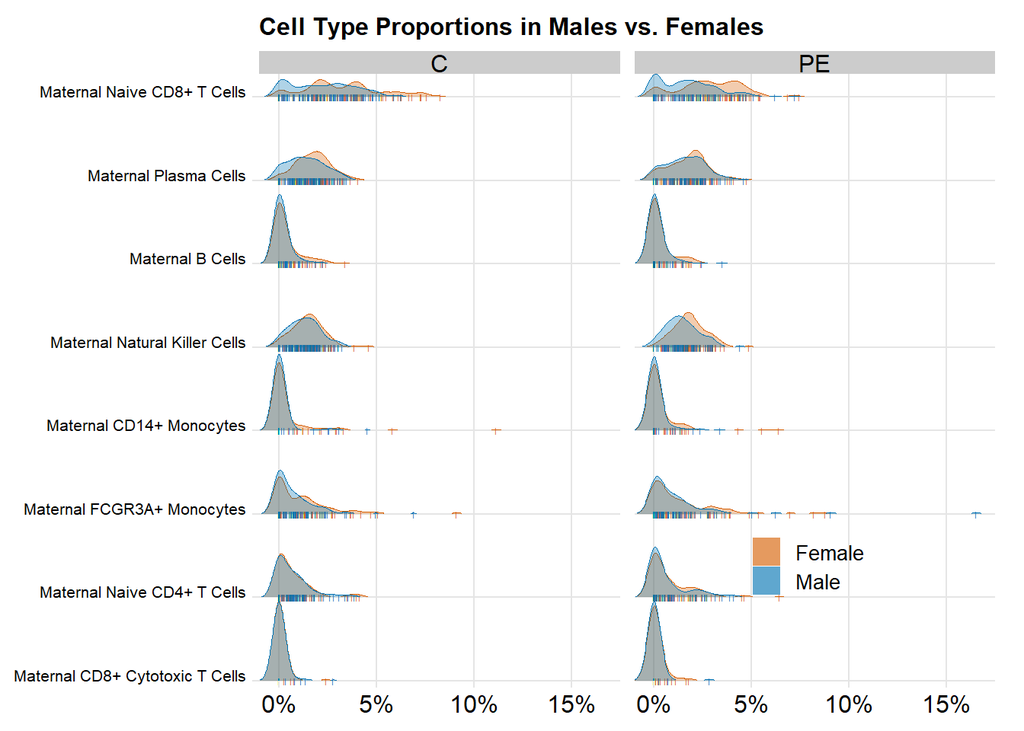

```r
maternal <-  ggplot(long.maternal, aes(x = Proportion, y = Cell.Type, color = sex, point_color = sex, fill = sex)) +
  geom_density_ridges(
    jittered_points = TRUE, scale = .95, rel_min_height = .01,
    point_shape = "|", point_size = 1, size = 0.25,
    position = position_points_jitter(height = 0)
  ) +
  ylab("Cell Type") +
  scale_y_discrete(expand = c(0, 0)) +
  scale_x_continuous(expand = c(0, 0), name = "Cell Type Proportion", labels = scales::percent_format(accuracy = 1)) +
  scale_fill_manual(values = c("#D55E0050", "#0072B250"), labels = c("Female", "Male")) +
  scale_color_manual(values = c("#D55E00", "#0072B2"), guide = "none") +
  scale_discrete_manual("point_color", values = c("#D55E00", "#0072B2"), guide = "none") +
  coord_cartesian(clip = "off") +
  guides(fill = guide_legend(
    override.aes = list(
      fill = c("#D55E00A0", "#0072B2A0"),
      color = NA, point_color = NA)
    )
  ) +
  ggtitle("Cell Type Proportions in Males vs. Females") +
  theme_ridges(center = TRUE) +
  theme(legend.title = element_blank(), legend.position = c(.65, .2), legend.text = element_text(size = 10), axis.title.x=element_blank(), plot.title = element_text(size = 12), axis.text.y = element_text(size = 8), axis.title.y = element_blank()) + facet_wrap(phenotype)

maternal
```

```r
#ggsave(here("results", "GSE75010", paste0("/", Sys.Date(), "maternal_cell_type_props_male_v_female_preeclampsia_facet_wrap.png")))
```

```r
long.maternal %>% group_by(phenotype, Cell.Type) %>% summarise(median = median(Proportion))
```

```
## # A tibble: 16 x 3
## # Groups:   phenotype [2]
##    phenotype    Cell.Type                        median
##    <fct>        <fct>                             <dbl>
##  1 Control      Maternal CD8+ Cytotoxic T Cells 0
##  2 Control      Maternal Naive CD4+ T Cells     0.00458
##  3 Control      Maternal FCGR3A+ Monocytes      0.00418
##  4 Control      Maternal CD14+ Monocytes        0
##  5 Control      Maternal Natural Killer Cells   0.0141
##  6 Control      Maternal B Cells                0
##  7 Control      Maternal Plasma Cells           0.0156
##  8 Control      Maternal Naive CD8+ T Cells     0.0264
##  9 Preeclampsia Maternal CD8+ Cytotoxic T Cells 0
## 10 Preeclampsia Maternal Naive CD4+ T Cells     0.00166
## 11 Preeclampsia Maternal FCGR3A+ Monocytes      0.00642
## 12 Preeclampsia Maternal CD14+ Monocytes        0
## 13 Preeclampsia Maternal Natural Killer Cells   0.0162
## 14 Preeclampsia Maternal B Cells                0
## 15 Preeclampsia Maternal Plasma Cells           0.0178
## 16 Preeclampsia Maternal Naive CD8+ T Cells     0.0230
```

```r
ct.prop.panel <- ggarrange(fetal.panel, maternal.panel, labels = "AUTO", common.legend = TRUE, legend = "bottom", font.label = list(size = 24, face = "bold", color = "black"))
#ggexport(ct.prop.panel, width = 1920, height = 1080, filename = here("results", "GSE75010", paste0(Sys.Date(), "_fetal_maternal_proportions.png")))
```

Beta transformation function to accommodate 0’s in the cell types where 0’s are predicted.

```r
beta_transform <- function(x, n) {
  return((1/n)*(x*(n-1)+0.5))
}
```

Function to run beta regressions over the outcomes of interest.

```r
# run beta regression models with multiple outcomes, the same set of covariates, and a dataset that includes all outcomes and covariates.
# outcomes is a character vector
# covariates is a character vector
# data is a 2d dataframe suitable for regression
beta_reg_models <- function(outcomes, covariates, data) {
  # Initialize empty list to store fitted regression models
  models <- list()
  # Loop over outcomes of interest
  for(outcome in outcomes) {
    # transform the data to accomodate 0s for beta regression if necessary
    if (0 %in% data[, outcome]) {
      data[, outcome] <- beta_transform(data[, outcome], nrow(data))
    }
    formula <- as.formula(
      paste0(outcome, " ~ ", paste(covariates, collapse = " + "))
    )
    models[[outcome]] <- tidy(x = betareg(formula = formula, data = data), data = data, conf.int = TRUE, conf.level = .95)
  }
  return(models)
}

# Same function as above but returns model fit statistics
beta_reg_model_fits <- function(outcomes, covariates, data) {
  # Initialize empty list to store fitted regression models
  model_fits <- list()
  # Loop over outcomes of interest
  for(outcome in outcomes) {
    # transform the data to accomodate 0s for beta regression if necessary
    if (0 %in% data[, outcome]) {
      data[, outcome] <- beta_transform(data[, outcome], nrow(data))
    }
    formula <- as.formula(
      paste0(outcome, " ~ ", paste(covariates, collapse = " + "))
    )
    model_fits[[outcome]] <- glance(x = betareg(formula = formula, data = data), data = data)
  }
  return(model_fits)
}
```

Run a model across all the cell types. TODO Model Fit Statistics, low pseudo-r-sq, possibly precision parameter optimization required?

```r
# Set the covariates vector, including the exposure at the front
covariates <- c("phenotype", "sex", "ga", "batch")
# Set the outcomes to be modelled vector, the cell types
# Get the column positions that correspond to cell type proportions
cell.types <- grepl("Fetal|Maternal", colnames(merged))
# Make the names syntactically valid
colnames(merged) <- make.names(colnames(merged))
# Pull the relevant columns
outcomes <- colnames(merged)[cell.types]
# Check if some cell types are all zeros
merged %>%
  dplyr::select(outcomes) %>%
  colSums()
```

```
## Note: Using an external vector in selections is ambiguous.
## i Use `all_of(outcomes)` instead of `outcomes` to silence this message.
## i See <https://tidyselect.r-lib.org/reference/faq-external-vector.html>.
```

```
##         Fetal.Mesenchymal.Stem.Cells                Fetal.CD14..Monocytes
##                         18.852312392                          5.249060480
##         Fetal.CD8..Cytotoxic.T.Cells             Fetal.Naive.CD4..T.Cells
##                          0.487852561                          0.001013123
##             Fetal.Naive.CD8..T.Cells         Fetal.Natural.Killer.T.Cells
##                         28.424387172                          0.388133330
##                        Fetal.B.Cells               Fetal.Cytotrophoblasts
##                          0.260338323                         97.249698859
##           Fetal.GZMK..Natural.Killer            Fetal.Memory.CD4..T.Cells
##                          5.534243360                          0.263568745
##                 Fetal.Hofbauer.Cells   Fetal.Plasmacytoid.Dendritic.Cells
##                         24.575397878                         10.569437325
##           Fetal.GZMB..Natural.Killer              Fetal.Endothelial.Cells
##                          0.031716184                         15.718393340
##            Fetal.Syncytiotrophoblast                    Fetal.Fibroblasts
##                         69.106844167                          2.408316064
##      Fetal.Nucleated.Red.Blood.Cells Fetal.Proliferative.Cytotrophoblasts
##                          6.480346434                          3.476703276
##      Maternal.CD8..Cytotoxic.T.Cells          Maternal.Naive.CD4..T.Cells
##                          0.222793702                          2.410888735
##           Maternal.FCGR3A..Monocytes             Maternal.CD14..Monocytes
##                          3.746896752                          0.981199605
##        Maternal.Natural.Killer.Cells                     Maternal.B.Cells
##                          5.015130510                          0.823158740
##                Maternal.Plasma.Cells          Maternal.Naive.CD8..T.Cells
##                          5.349131915                          8.418197675
##      Fetal.Extravillous.Trophoblasts
##                         13.954839353
```

```r
# Exclude Fetal Naive CD4+ T Cells and Fetal B Cells
outcomes <- outcomes[!(outcomes %in% c("Fetal.Naive.CD4..T.Cells", "Fetal.B.Cells"))]

models <- beta_reg_models(outcomes, covariates, merged)
fits <- beta_reg_model_fits(outcomes , covariates, merged)
```

Comparing fixed precision parameter, Phi, against variable precision parameter modeled with all covariates.

```r
# Fixed dispersion
#mod <- betareg(as.formula(paste0("fibroblasts", " ~ ", paste(covariates, collapse = " + "))), data = merged)
# Variable dispersion model with all covariates, sex and phenotype not significant, some batch dummies are significant
#mod2 <- betareg(as.formula(paste0("fibroblasts", " ~ ", paste(covariates, collapse = " + "), " | ", paste(covariates, collapse = " + "))), #data = merged)
#lrtest(mod, mod2)
```

Model fit diagnostics plots can be accessed with plot.

```r
#plot(mod)
```

Pull all model effect estimates and combine to a single tibble for graphing.

```r
pull_estimates <- function(data) {
  return(
    data %>%
      filter(term == "phenotypePE") %>%
      dplyr::select(estimate,
                    conf.low,
                    conf.high,
                    p.value) %>%
      mutate(
        or = exp(estimate),
        lower = exp(conf.low),
        upper = exp(conf.high)
      )
  )
}
estimates <- lapply(X = models, FUN = pull_estimates)
# Collapse list of model estimates to a single tibble
estimates <- Reduce(rbind, estimates)
# Add cell_type names and reorganize columns
estimates <-
  estimates %>%
  mutate(Cell.Type = names(models)) %>%
  dplyr::select(Cell.Type, everything())
# Recode cell type names
# First, recode all ".." to "+ "
estimates$Cell.Type <- str_replace_all(string = estimates$Cell.Type, pattern = "\\.{2}", replacement = "+ ")
# Then, replace remaining "." with " "
estimates$Cell.Type <- str_replace_all(string = estimates$Cell.Type, pattern = "\\.{1}", replacement = " ")

# Save results
#write.csv(estimates, paste0(results_dir, "beta_models_estimates.csv"))
```

Make modifications to the results table for graphing.

```r
# Create an indicator variable if significant
estimates$is.sig <- estimates$p.value < .05

# Create a fetal/maternal indicator to reorder by
estimates$is.fetal <- grepl("^Fetal", estimates$Cell.Type)
# Set factor variable with true as the reference level
estimates$is.fetal <- factor(estimates$is.fetal, levels = c(F, T))

# Arrange cell types by descending Odds Ratio within each fetal/maternal group
estimates.graph <-
  estimates %>%
  group_by(is.fetal) %>%
  arrange(desc(or), .by_group = T)

# Get cell types ordered from above
factor.order <- estimates.graph$Cell.Type
#saveRDS(factor.order, paste0(data_dir, "beta_or_ranked_cell_type_factor_", Sys.Date(), ".rda"))

# Relevel the factor with the ordered cell types
estimates.graph$Cell.Type <- factor(estimates.graph$Cell.Type, levels = factor.order)
```

Forest plot code

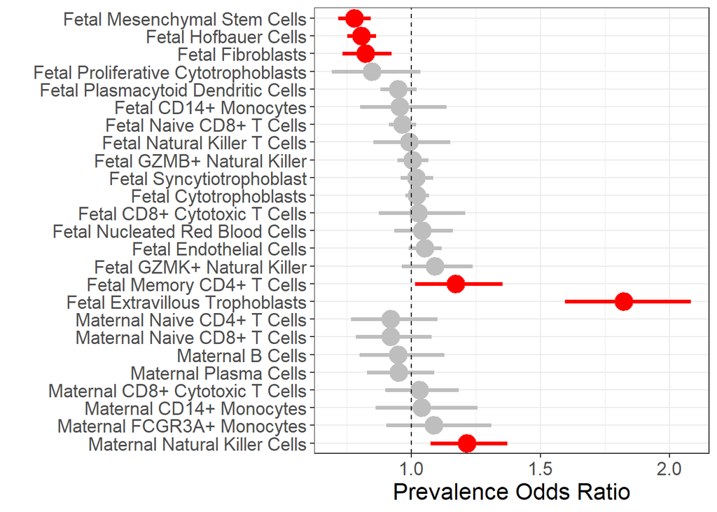

```r
forest <- ggplot(data=estimates.graph,
                       aes(x=Cell.Type, y=or, ymin=lower, ymax=upper, color = is.sig)) +
    geom_pointrange(position=position_dodge2(width=1), size=1.3) +
    geom_hline(yintercept=1, linetype=2) +
    theme_bw() +
    theme(text = element_text(size=16),
          legend.position = 'none') +
    xlab('') + ylab('Prevalence Odds Ratio') +
    coord_flip() +
    scale_color_manual(values = c("grey", "red"))

forest
```

```r
#ggsave(paste0(results_dir, "beta_forest_", Sys.Date(), ".png"), device = png())
```

Pull all sex model effect estimates and combine to a single tibble for graphing.

```r
pull_estimates <- function(data) {
  return(
    data %>%
      filter(term == "sexM") %>%
      dplyr::select(estimate,
                    conf.low,
                    conf.high,
                    p.value) %>%
      mutate(
        or = exp(estimate),
        lower = exp(conf.low),
        upper = exp(conf.high)
      )
  )
}
estimates <- lapply(X = models, FUN = pull_estimates)
# Collapse list of model estimates to a single tibble
estimates <- Reduce(rbind, estimates)
# Add cell_type names and reorganize columns
estimates <-
  estimates %>%
  mutate(Cell.Type = names(models)) %>%
  dplyr::select(Cell.Type, everything())
# Recode cell type names
# First, recode all ".." to "+ "
estimates$Cell.Type <- str_replace_all(string = estimates$Cell.Type, pattern = "\\.{2}", replacement = "+ ")
# Then, replace remaining "." with " "
estimates$Cell.Type <- str_replace_all(string = estimates$Cell.Type, pattern = "\\.{1}", replacement = " ")

# Save results
#write.csv(estimates, paste0(results_dir, "beta_models_estimates.csv"))
```

Make modifications to the results table for graphing.

```r
# Create an indicator variable if significant
estimates$is.sig <- estimates$p.value < .05

# Create a fetal/maternal indicator to reorder by
estimates$is.fetal <- grepl("^Fetal", estimates$Cell.Type)
# Set factor variable with true as the reference level
estimates$is.fetal <- factor(estimates$is.fetal, levels = c(F, T))

# Arrange cell types by descending Odds Ratio within each fetal/maternal group
estimates.graph <-
  estimates %>%
  group_by(is.fetal) %>%
  arrange(desc(or), .by_group = T)

# Get cell types ordered from above
factor.order <- estimates.graph$Cell.Type
#saveRDS(factor.order, paste0(data_dir, "beta_or_ranked_cell_type_factor_", Sys.Date(), ".rda"))

# Relevel the factor with the ordered cell types
estimates.graph$Cell.Type <- factor(estimates.graph$Cell.Type, levels = factor.order)
```

Sex forest plot code

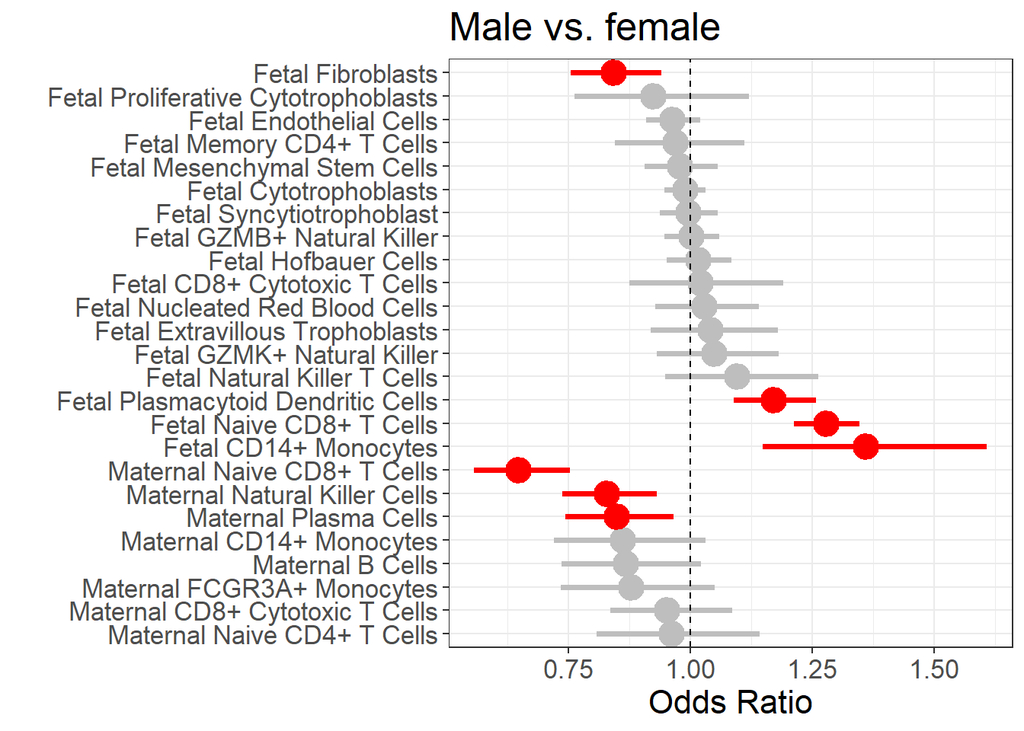

```r
forest <- ggplot(data=estimates.graph,
                       aes(x=Cell.Type, y=or, ymin=lower, ymax=upper, color = is.sig)) +
    geom_pointrange(position=position_dodge2(width=1), size=1.3) +
    geom_hline(yintercept=1, linetype=2) +
    theme_bw() +
    theme(text = element_text(size=16),
          legend.position = 'none') +
    xlab('') + ylab('Odds Ratio') +
    coord_flip() +
    scale_color_manual(values = c("grey", "red"))

forest + ggtitle("Male vs. female")
```

```r
#ggsave(paste0(results_dir, "sex_beta_forest_", Sys.Date(), ".png"), device = png())
```